# Retail Demand Forecasting - Capstone Project

Domenico Monteleone

2025-05-27

📌 Project Introduction and Objective This project was developed as part of the Google Data Analytics Capstone and focuses on analyzing product demand in the retail sector.

📈 An interactive version is available on Tableau Public:[https://public.tableau.com/app/profile/domenico.monteleone/viz/Dashboard-retail-demand-forecast/Dashbordretaildemandforecast]

**Objective:** Analyze historical order data to identify trends, seasonality, and provide strategic insights for forecasting future demand.

# 🧹 Data Loading and Cleaning

**The dataset is first loaded and cleaned. Here’s a summary of the key steps:**

Renamed columns to lowercase and replaced spaces with underscores.

Converted order_demand to numeric, handling negative values.

Removed rows with missing values.

Created a month column to aggregate data.

# 📊 Analysis 1: Aggregated Monthly Demand

**This chart shows how total demand has evolved over time on a monthly basis.**

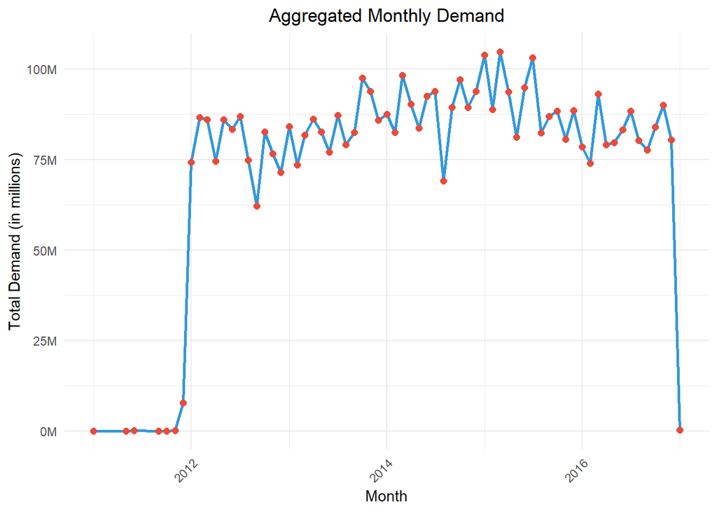

# 📈 Analysis 2: Seasonality

**Demand patterns are evaluated by month and year to identify recurring trends.**

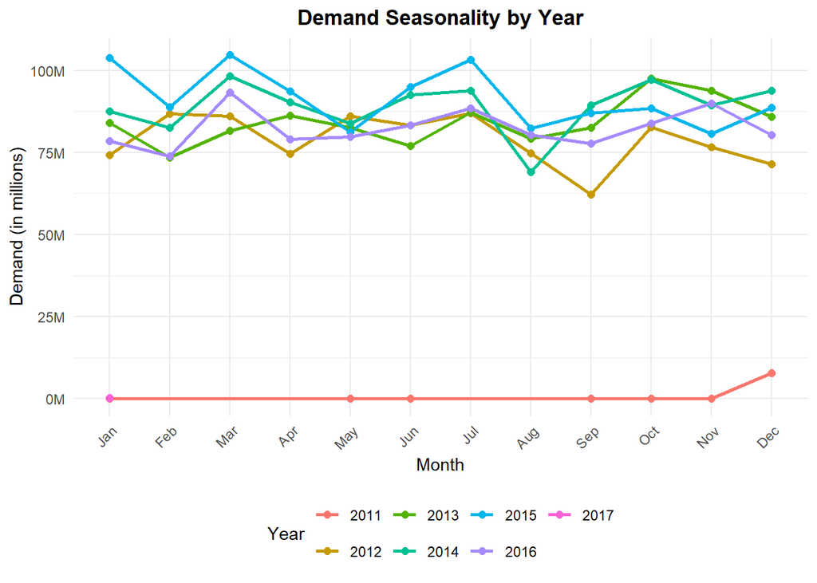

# 🔮 Analysis 3: 3-6 Months Moving Average Forecast

**Applied a rolling average to smooth demand and help forecast future trends.**

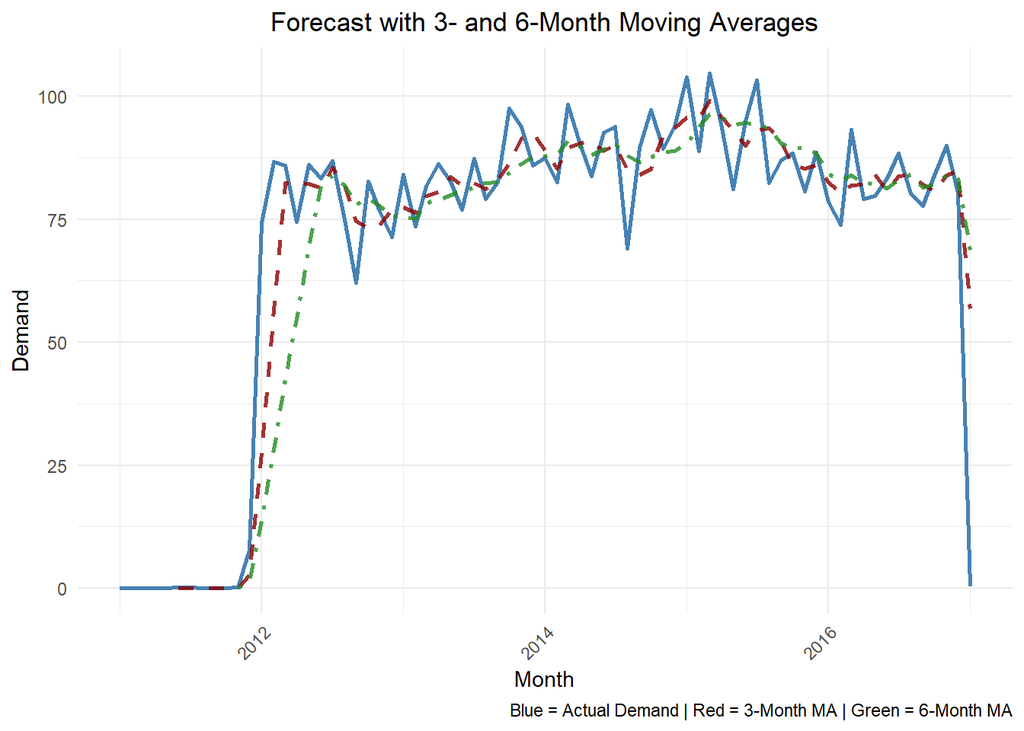

# 📈 Analysis 4: Top 5 products

**Filtered the top 5 products and visualized them with a line chart.**

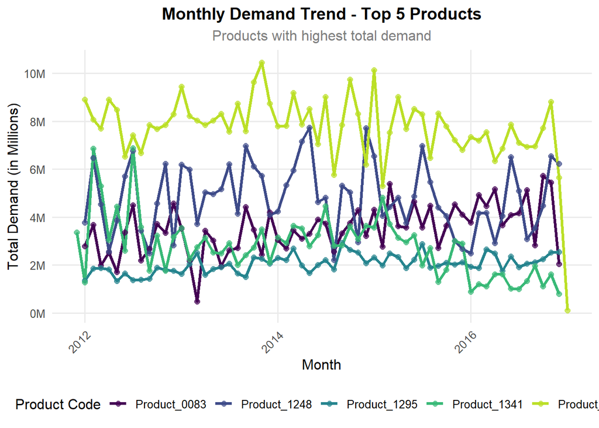

# 📊 Analysis 5: Annual Demand by Warehouse and Product Category

**Color legend**  
🟥 Dark red = High demand  
🟧 Orange = Medium demand  
🟨 Light yellow = Low demand

Use the filters above the **Warehouse** and **Product Category** columns to explore the data.  
The **Total** column sums the annual demand for each combination. Values are color-coded accordingly.

| Warehouse | Product Category | 2013 | 2014 | 2015 | 2016 | 2011 | 2012 | 2017 | Total |
| --- | --- | --- | --- | --- | --- | --- | --- | --- | --- |
| Whse_A | Category_001 | 232 | 1151 | 57 | 304 | 0 | 0 | 0 | 1744 |
| Whse_A | Category_003 | 21168 | 21744 | 32148 | 33741 | 108 | 22266 | 0 | 131175 |
| Whse_A | Category_005 | 255600 | 280000 | 132500 | 127500 | 0 | 315900 | 0 | 1111500 |
| Whse_A | Category_006 | 2151230 | 2082483 | 2277526 | 1943283 | 21504 | 3009885 | 0 | 11485911 |
| Whse_A | Category_007 | 467230 | 536028 | 665865 | 595536 | 1556 | 517509 | 0 | 2783724 |
| Whse_A | Category_008 | 386 | 338 | 385 | 771 | 0 | 21 | 0 | 1901 |
| Whse_A | Category_009 | 128187 | 147138 | 225839 | 228504 | 920 | 135187 | 0 | 865775 |
| Whse_A | Category_010 | 3436 | 2016 | 1902 | 2120 | 0 | 2483 | 0 | 11957 |
| Whse_A | Category_011 | 1520 | 2077 | 1419 | 2622 | 0 | 2299 | 0 | 9937 |
| Whse_A | Category_012 | 680 | 671 | 863 | 6515 | 0 | 17 | 0 | 8746 |

[output cut: 84 more lines]

# Data Export for Tableau

```r
write.csv(df, "data/Historical_Product_Demand_Tableau.csv", row.names = FALSE)
```